# Bioestadística Fundamental

Departamento de Estadística, Sede Bogotá

## Contenido

### Parte I: El diseño factorial $3^k$

- Motivación: factores cuantitativos con tres niveles.
- El diseño $3^2$: ejemplo completo en papa.
- El diseño $3^3$: extensión a tres factores.
- El diseño $3^k$ general.

### Parte II: Confusión en el diseño $3^k$

- El diseño $3^k$ en tres bloques.
- El diseño $3^k$ en nueve bloques.
- El diseño $3^k$ en $3^p$ bloques.

### Parte III: Réplica fraccionada del $3^k$

- La fracción un tercio del diseño $3^k$.
- Otros diseños $3^{k-p}$ fraccionados.

### Parte IV: Factoriales con niveles mixtos

- Factores a dos y tres niveles simultáneamente.
- Factores a dos y cuatro niveles simultáneamente.
- Taller en clase.

Diseños Factoriales de Tres Niveles y de Niveles Mixtos

Cuando un factor cuantitativo (dosis, riego, densidad) puede tomar más de dos valores, ¿cómo diseñar el experimento para detectar no solo tendencias lineales, sino también curvatura?

## Motivación: más allá de dos niveles

Los diseños factoriales $2^k$ son muy eficientes, pero solo permiten estimar el efecto **lineal** de cada factor entre su nivel bajo y su nivel alto. En muchos problemas agrícolas colombianos, el agrónomo sospecha que la respuesta no es una línea recta, sino que existe un **punto óptimo intermedio**.

Ejemplo: en papa de altiplano, una dosis baja de nitrógeno puede ser insuficiente y una dosis muy alta puede causar exceso de follaje y caída en el rendimiento de tubérculo. Solo con **tres niveles** (bajo, medio, alto) es posible detectar esta curvatura.

## ¿Por qué tres niveles?

Diseño $2^k$

Con dos niveles (bajo, alto) solo se puede ajustar una recta. Si la verdadera relación tiene un máximo intermedio, el diseño $2^k$ es incapaz de detectarlo.

Diseño $3^k$

Con tres niveles (bajo, medio, alto) es posible separar el efecto **lineal** del efecto **cuadrático** (curvatura) de cada factor cuantitativo.

Definición: diseño factorial $3^k$

Diseño factorial con $k$ factores, cada uno a **tres niveles** (codificados $-1, 0, +1$ o bajo/medio/alto). Tiene $3^k$ combinaciones de tratamiento (corridas).

## El diseño $3^2$: motivación agrícola

Un agrónomo del altiplano cundiboyacense estudia el rendimiento de **papa criolla** (t/ha) en función de dos factores cuantitativos, cada uno a tres niveles:

**Factor A: Fertilización NPK**  
Bajo / Medio / Alto  
(150 / 300 / 450 kg/ha)

**Factor B: Lámina de riego**  
Bajo / Medio / Alto  
(20 / 35 / 50 mm/semana)

$3^2=9$ combinaciones de tratamiento, con $n=3$ parcelas (réplicas) por combinación: $N=27$ parcelas en total.

## Datos del experimento de papa criolla

Rendimiento (t/ha) registrado en las 27 parcelas, organizadas por combinación de NPK y riego:

| NPK | Riego | Rep 1 | Rep 2 | Rep 3 | Media celda |
| --- | --- | --- | --- | --- | --- |
| Bajo | Bajo | 17.2 | 17.7 | 20.2 | 18.37 |
| Bajo | Medio | 22.1 | 22.2 | 24.4 | 22.90 |
| Bajo | Alto | 24.6 | 22.2 | 23.0 | 23.27 |
| Medio | Bajo | 22.4 | 24.7 | 23.5 | 23.53 |
| Medio | Medio | 29.6 | 29.2 | 28.2 | 29.00 |
| Medio | Alto | 34.5 | 32.7 | 29.2 | 32.13 |
| Alto | Bajo | 27.0 | 25.3 | 24.5 | 25.60 |
| Alto | Medio | 32.7 | 31.6 | 32.0 | 32.10 |
| Alto | Alto | 34.1 | 32.6 | 36.2 | 34.30 |

## Tabla de medias y gráfico de interacción

| NPK Riego | Bajo | Medio | Alto | Media NPK |
| --- | --- | --- | --- | --- |
| Bajo | 18.37 | 22.90 | 23.27 | 21.51 |
| Medio | 23.53 | 29.00 | 32.13 | 28.22 |
| Alto | 25.60 | 32.10 | 34.30 | 30.67 |
| **Media Riego** | 22.50 | 28.00 | 29.90 | **26.80** |

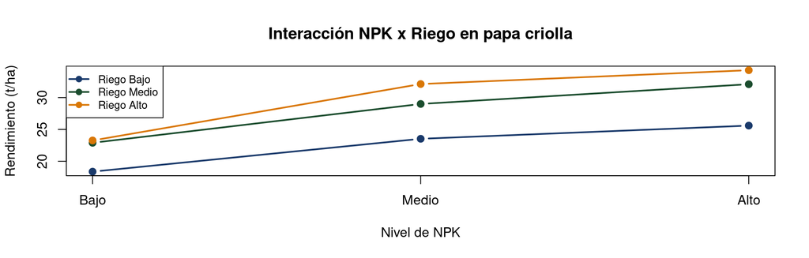

## Componentes lineal y cuadrático

Con tres niveles equiespaciados, los 2 grados de libertad de cada factor principal se descomponen mediante **contrastes polinomiales ortogonales**:

Contrastes polinomiales (3 niveles)

$$L = -1\cdot\bar y_{Bajo} + 0\cdot\bar y_{Medio} + 1\cdot\bar y_{Alto} \quad \text{(componente lineal)}$$
$$Q = 1\cdot\bar y_{Bajo} - 2\cdot\bar y_{Medio} + 1\cdot\bar y_{Alto} \quad \text{(componente cuadrático)}$$

Cada componente aporta exactamente **1 grado de libertad**. Para un factor a 3 niveles: $2$ gl $=1$ gl (lineal) $+1$ gl (cuadrático).

## Descomposición de los 8 grados de libertad del $3^2$

En el diseño $3^2$ hay $3^2-1=8$ grados de libertad de tratamiento, que se descomponen en componentes lineales (L) y cuadráticos (Q) de cada factor y sus interacciones:

| Fuente | gl |
| --- | --- |
| NPK (lineal) | 1 |
| NPK (cuadrático) | 1 |
| Riego (lineal) | 1 |
| Riego (cuadrático) | 1 |
| NPK(L)×Riego(L) | 1 |
| NPK(Q)×Riego(L) | 1 |
| NPK(L)×Riego(Q) | 1 |
| NPK(Q)×Riego(Q) | 1 |
| Total tratamientos | 8 |

## Tabla ANOVA: NPK y Riego (efectos principales)

| Fuente | SC | gl | CM | F | valor-p |
| --- | --- | --- | --- | --- | --- |
| NPK | 404.5 | 2 | 202.26 | 90.64 | $4.0\times10^{-10}$ |
| Riego | 265.9 | 2 | 132.93 | 59.57 | $1.2\times10^{-8}$ |
| NPK $\times$ Riego | 15.3 | 4 | 3.82 | 1.71 | 0.191 |
| Error | 40.2 | 18 | 2.23 |  |  |
| Total | 725.9 | 26 |  |  |  |

Tanto NPK como Riego son altamente significativos ($\alpha=0.05$); la interacción global no lo es ($p=0.191$).

## Tabla ANOVA: descomposición lineal/cuadrática

| Fuente | SC | gl | CM | F | valor-p |
| --- | --- | --- | --- | --- | --- |
| NPK lineal | 377.1 | 1 | 377.1 | 169.04 | $1.4\times10^{-10}$ |
| NPK cuadrático | 27.3 | 1 | 27.3 | 12.24 | 0.0026 |
| Riego lineal | 246.5 | 1 | 246.5 | 110.43 | $4.1\times10^{-9}$ |
| Riego cuadrático | 19.4 | 1 | 19.4 | 8.71 | 0.0085 |
| NPK(L)$\times$Riego(L) | 10.8 | 1 | 10.8 | 4.85 | 0.0409 |
| NPK(Q)$\times$Riego(L) | 3.2 | 1 | 3.2 | 1.45 | 0.2438 |
| NPK(L)$\times$Riego(Q) | 0.0 | 1 | 0.0 | 0.00 | 0.9649 |
| NPK(Q)$\times$Riego(Q) | 1.2 | 1 | 1.2 | 0.54 | 0.4722 |
| Error | 40.2 | 18 | 2.23 |  |  |

## Interpretación: papa criolla

**Componente lineal de NPK** ($F=169.04$, $p<0.001$): el rendimiento crece de forma marcadamente lineal al aumentar la dosis de fertilizante en el rango estudiado.

**Componente cuadrático de NPK** ($F=12.24$, $p=0.0026$): significativo pero pequeño frente al lineal; sugiere un leve aplanamiento de la curva entre las dosis Media y Alta, no un máximo claro dentro del rango.

**Interacción NPK(L)$\times$Riego(L)** ($p=0.0409$): el efecto lineal del fertilizante depende levemente del nivel de riego; con más agua, el incremento marginal de NPK es algo mayor.

## El diseño $3^3$: extensión a tres factores

Si el agrónomo desea incorporar un tercer factor cuantitativo a tres niveles, por ejemplo la **densidad de siembra** de la papa criolla (baja: 40 000, media: 55 000, alta: 70 000 plantas/ha), se obtiene un diseño $3^3$.

Diseño $3^3$: NPK $\times$ Riego $\times$ Densidad

$3^3 = 27$ combinaciones de tratamiento. Con $n=2$ réplicas, $N=54$ parcelas.

Grados de libertad de tratamiento: $3^3-1=26$, que se reparten en 3 efectos principales (2 gl cada uno, separables en L y Q), 3 interacciones de dos factores (4 gl cada una) y 1 interacción de tres factores (8 gl).

## Descomposición de grados de libertad del $3^3$

| Fuente | gl |
| --- | --- |
| NPK (A) | 2 |
| Riego (B) | 2 |
| Densidad (C) | 2 |
| A$\times$B | 4 |
| A$\times$C | 4 |
| B$\times$C | 4 |
| A$\times$B$\times$C | 8 |
| Total tratamientos | 26 |

Cada efecto principal (2 gl) puede descomponerse en lineal y cuadrático; cada interacción de 2 factores (4 gl) en cuatro componentes LL, LQ, QL, QQ; la de 3 factores (8 gl) en ocho componentes LLL, LLQ, …, QQQ.

## Ejemplo conceptual: $3^3$ con densidad de siembra

Supóngase que al añadir Densidad de siembra al experimento de papa criolla se observan estas medias marginales aproximadas (t/ha):

| Densidad | Baja | Media | Alta |
| --- | --- | --- | --- |
| Rendimiento medio | 24.1 | 28.9 | 27.3 |

El patrón Baja $<$ Media $>$ Alta sugiere un **componente cuadrático fuerte** en Densidad: existe una densidad óptima intermedia, y sembrar demasiado denso reduce el rendimiento por competencia entre plantas.

Sin el nivel intermedio (diseño $2^k$), este óptimo pasaría completamente inadvertido.

## El diseño $3^k$ general

Diseño factorial $3^k$

Número de corridas (combinaciones de tratamiento): $\quad 3^k$
$$\text{Grados de libertad de tratamientos: } 3^k - 1$$

A medida que $k$ crece, el número de corridas se dispara: $3^2=9$, $3^3=27$, $3^4=81$, $3^5=243$. Esto motiva dos estrategias que se desarrollan a continuación:

**Confusión en bloques**: ejecutar el experimento completo, pero repartido en bloques manejables.

**Réplica fraccionada**: ejecutar solo una fracción de las $3^k$ combinaciones.

Confusión en el diseño $3^k$

¿Cómo ejecutar un diseño $3^k$ grande cuando la capacidad experimental (invernadero, lote, día de siembra) es limitada?

## Motivación: bloques de capacidad limitada

En el diseño $3^3$ de papa criolla (27 combinaciones), puede ocurrir que el lote experimental solo permita sembrar **9 parcelas por día** de siembra, o que cada invernadero solo tenga capacidad para 9 macetas. Sembrar las 27 combinaciones el mismo día es inviable.

Confusión (confounding)

Técnica que reparte las $3^k$ combinaciones en bloques, sacrificando deliberadamente la posibilidad de estimar cierta interacción de orden alto (que se **confunde** con el efecto de bloque), a cambio de poder ejecutar el experimento por partes.

## El diseño $3^k$ en tres bloques

Para el $3^2$ de papa criolla (9 combinaciones), si solo se dispone de **3 parcelas por bloque** (por ejemplo, 3 fincas colaboradoras, cada una con capacidad para 3 parcelas), se reparten las 9 combinaciones en 3 bloques de 3.

Se utiliza un **componente de interacción**, por ejemplo $AB$ o $AB^2$, para definir los bloques: las combinaciones que comparten el mismo valor de ese componente forman un bloque.

[output not shown]

El precio: ya no es posible estimar limpiamente toda la interacción NPK$\times$Riego, pues parte de ella queda confundida con la diferencia entre fincas (bloques).

## El diseño $3^k$ en nueve bloques

Si la limitación es aún mayor (por ejemplo, en un $3^3$ de 27 combinaciones solo se dispone de **3 parcelas por bloque**), se necesitan $27/3=9$ bloques.

Se utilizan **dos componentes de interacción independientes** (por ejemplo $ABC$ y $AB^2C^2$) para definir simultáneamente los 9 bloques de 3 parcelas cada uno. Cada componente usado para bloquear aporta 2 grados de libertad que quedan confundidos con bloques.

Ejemplo agrícola: nueve veredas distintas, cada una sembrando solo 3 parcelas del experimento $3^3$ de papa (NPK, Riego, Densidad) en la misma semana.

## El diseño $3^k$ en $3^p$ bloques

En general, un diseño $3^k$ puede dividirse en $3^p$ bloques de tamaño $3^{k-p}$, usando $p$ componentes de interacción independientes para definir la pertenencia a cada bloque.

Confusión del $3^k$ en $3^p$ bloques

Número de bloques: $3^p$ Tamaño de cada bloque: $3^{k-p}$

A mayor $p$, los bloques son más pequeños y manejables, pero se confunden más componentes de interacción: existe un compromiso entre factibilidad operativa y pérdida de información.

Regla práctica: seleccionar para la confusión las interacciones de **orden más alto**, pues suelen ser las menos relevantes agronómicamente (ej. la interacción triple NPK$\times$Riego$\times$Densidad).

Réplica fraccionada del diseño $3^k$

¿Es necesario ejecutar todas las $3^k$ combinaciones, o basta con una fracción cuidadosamente elegida?

## Motivación: reducir el número de corridas

Cuando se estudian varios factores cuantitativos a tres niveles (por ejemplo NPK, Riego, Densidad y un cuarto factor como variedad de papa con tres clones), el diseño completo $3^4=81$ corridas resulta costoso e impráctico en campo.

Réplica fraccionada $3^{k-p}$

Subconjunto de $3^{k-p}$ combinaciones (una fracción $1/3^p$ del diseño completo), seleccionado de modo que los efectos principales y las interacciones de interés permanezcan estimables, al costo de confundir los efectos de orden superior entre sí.

## La fracción un tercio del diseño $3^k$

La fracción más simple es la **fracción $1/3$**: se ejecuta solo $3^{k-1}$ de las $3^k$ combinaciones, definida mediante un componente de interacción de orden $k$ (como $ABC\cdots$) fijado en un valor constante.

**Ejemplo agrícola:** en el $3^3$ de papa criolla (NPK, Riego, Densidad), en lugar de sembrar las 27 combinaciones, se siembran solo $3^2=9$, seleccionadas con el componente $ABC$ fijo. Se reduce el experimento a un tercio de su tamaño.

El costo: la interacción de tres factores ($ABC$, 8 gl) ya no puede estimarse, pues fue la base de la selección de la fracción; se confunde con la media general y queda fuera del análisis.

## Otros diseños $3^{k-p}$ fraccionados

De forma análoga, pueden construirse fracciones más pequeñas, $1/9$ ($3^{k-2}$), $1/27$ ($3^{k-3}$), etc., usando $p$ componentes de interacción independientes para definir la fracción.

A mayor $p$, menos corridas se requieren, pero se confunden más interacciones entre sí (mayor pérdida de resolución).

Útil en etapas exploratorias (tamizaje) con varios factores cuantitativos, antes de profundizar con un diseño completo en los factores más relevantes.

Ejemplo: con 4 factores agronómicos a 3 niveles (NPK, Riego, Densidad, Variedad), una fracción $3^{4-2}=9$ corridas permite un primer tamizaje, antes de un ensayo confirmatorio más completo.

Factoriales con niveles mixtos

¿Qué ocurre cuando los factores del experimento no tienen todos el mismo número de niveles?

## Factores a dos y tres niveles simultáneamente

En la práctica agrícola es común combinar un factor **cualitativo a dos niveles** (ej. variedad, sistema de siembra) con un factor **cuantitativo a tres niveles** (ej. dosis de un insumo). Esto da lugar a un diseño factorial de **niveles mixtos $2\times3$**.

Diseño factorial de niveles mixtos

Diseño factorial en el que los factores no comparten el mismo número de niveles. El número total de combinaciones es el producto de los niveles de cada factor (ej. $2\times3=6$).

## Ejemplo agrícola: arroz, Variedad x Dosis de fertilizante

En los Llanos Orientales se evalúa el rendimiento de **arroz** (t/ha) según dos factores:

**Factor A: Variedad** (2 niveles)  
V1 (tradicional) / V2 (mejorada)

**Factor B: Dosis de urea** (3 niveles)  
Baja / Media / Alta

$2\times3=6$ combinaciones de tratamiento, con $n=3$ parcelas por combinación: $N=18$ parcelas.

## Datos: arroz, Variedad x Dosis

| Variedad | Dosis | Rep 1 | Rep 2 | Rep 3 | Media celda |
| --- | --- | --- | --- | --- | --- |
| V1 | Baja | 4.80 | 5.39 | 5.44 | 5.21 |
| V1 | Media | 5.58 | 5.79 | 5.90 | 5.76 |
| V1 | Alta | 6.61 | 6.48 | 6.70 | 6.60 |
| V2 | Baja | 5.77 | 5.33 | 5.99 | 5.70 |
| V2 | Media | 7.10 | 7.30 | 6.37 | 6.92 |
| V2 | Alta | 8.18 | 8.12 | 7.72 | 8.01 |

Media general $\bar y_{..}=6.365$ t/ha.

## Gráfico de interacción: arroz

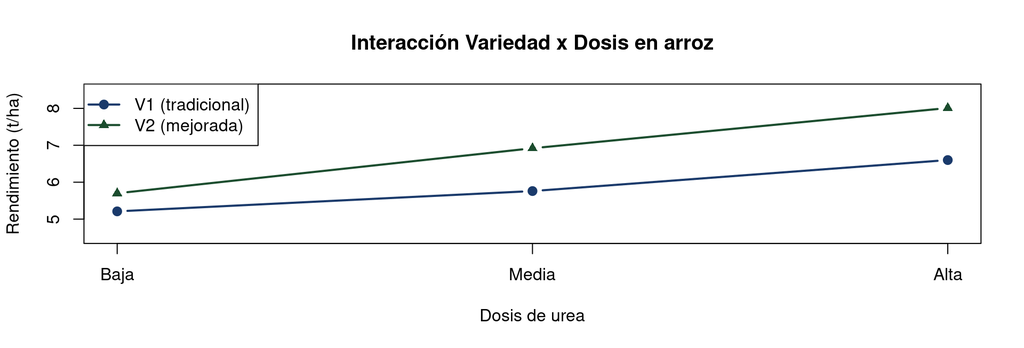

Las líneas no son paralelas: V2 responde con mayor pendiente al incremento de dosis que V1, lo que sugiere una posible interacción.

## Tabla ANOVA: arroz, Variedad x Dosis (niveles mixtos $2\times3$)

| Fuente | SC | gl | CM | F | valor-p |
| --- | --- | --- | --- | --- | --- |
| Variedad | 4.69 | 1 | 4.69 | 48.50 | $1.5\times10^{-5}$ |
| Dosis | 10.25 | 2 | 5.13 | 53.00 | $1.1\times10^{-6}$ |
| Variedad $\times$ Dosis | 0.69 | 2 | 0.34 | 3.55 | 0.061 |
| Error | 1.16 | 12 | 0.10 |  |  |
| Total | 16.79 | 17 |  |  |  |

gl de tratamientos $=2\times3-1=5=1(\text{Variedad})+2(\text{Dosis})+2(\text{Variedad}\times\text{Dosis})$.

## Interpretación: arroz

**Variedad** ($F=48.50$, $p<0.001$): la variedad mejorada V2 (media global 6.88 t/ha) supera significativamente a la tradicional V1 (5.85 t/ha).

**Dosis de urea** ($F=53.00$, $p<0.001$): el rendimiento aumenta de forma marcada y aproximadamente lineal con la dosis (5.45, 6.34, 7.30 t/ha).

**Interacción** ($F=3.55$, $p=0.061$): no alcanza significancia al 5%, pero está cerca del umbral; la respuesta a la dosis tiende a ser algo más pronunciada en V2, lo que merece seguimiento en futuros ensayos.

## Factores a dos y cuatro niveles: flores de exportación

En un cultivo de **rosas de exportación** en la sabana de Bogotá se desea evaluar el efecto de dos factores con distinto número de niveles sobre el número de tallos exportables por planta.

**Factor A: Sistema de riego** (2 niveles)  
Goteo convencional / Goteo con fertirriego

**Factor B: Dosis de bioestimulante** (4 niveles)  
0, 1, 2, 3 mL/L

Diseño de niveles mixtos $2\times4=8$ combinaciones de tratamiento.

## Estructura conceptual: riego x bioestimulante en rosas

| Riego Bioestimulante | 0 mL/L | 1 mL/L | 2 mL/L | 3 mL/L |
| --- | --- | --- | --- | --- |
| Convencional | 38 | 41 | 44 | 45 |
| Fertirriego | 42 | 47 | 52 | 54 |

gl de tratamientos $=2\times4-1=7=1(\text{Riego})+3(\text{Bioestimulante})+3(\text{Riego}\times\text{Bioestimulante})$.

Conceptualmente: ambos sistemas de riego mejoran con mayor dosis de bioestimulante, pero el fertirriego parte de una base más alta y gana más tallos por unidad de dosis (posible interacción).

## Generalización: diseños de niveles mixtos

Diseño factorial de niveles mixtos $a\times b$

Número de corridas: $a\times b$ Grados de libertad de tratamientos: $ab-1$
$$gl_A = a-1 \qquad gl_B = b-1 \qquad gl_{A\times B}=(a-1)(b-1)$$

El principio se extiende a más de dos factores con distintos números de niveles, ej. $2\times3\times4$, manteniendo siempre que el número total de corridas es el producto de los niveles.

Si el factor a tres o más niveles es cuantitativo, sus grados de libertad pueden descomponerse en componentes lineal, cuadrático, etc., igual que en el diseño $3^k$.

## Errores comunes

Advertencia: errores frecuentes

- Tratar un factor cuantitativo a tres niveles como si fuera puramente cualitativo, perdiendo la posibilidad de estimar los componentes lineal y cuadrático.
- Olvidar que en un diseño $3^k$ confundido en bloques se pierde información sobre la(s) interacción(es) usada(s) para definir los bloques.
- Confundir una réplica fraccionada $3^{k-p}$ con un diseño $2^{k-p}$: las reglas de generadores y alias son distintas en cada caso.
- En diseños de niveles mixtos, calcular mal los grados de libertad de la interacción: no es $(a-1)+(b-1)$, sino $(a-1)(b-1)$.
- Interpretar un componente cuadrático significativo como evidencia automática de un máximo dentro del rango estudiado, sin graficar la curva de respuesta.

## Resumen general de la clase

| Diseño | Corridas | gl tratamientos |
| --- | --- | --- |
| $3^2$ | 9 | 8 |
| $3^3$ | 27 | 26 |
| $3^k$ en $3^p$ bloques | $3^k$ (en $3^p$ bloques de $3^{k-p}$) | $3^k-1$ (menos gl confundidos) |
| $3^{k-p}$ fraccionado | $3^{k-p}$ | $3^{k-p}-1$ |
| Niveles mixtos $a\times b$ | $a\times b$ | $ab-1$ |

La elección del diseño depende de cuántos niveles necesita cada factor para responder la pregunta agronómica, y de la capacidad operativa real del experimento.

## Taller en Clase

## Instrucciones

Para cada ejercicio:

1. Identifique el tipo de diseño (completo $3^k$, confundido en bloques, fraccionado, o de niveles mixtos).
2. Calcule el número de corridas y los grados de libertad de tratamientos.
3. Cuando se suministre información, complete o interprete la tabla ANOVA correspondiente.
4. Redacte una conclusión en el contexto agronómico del problema.

## Ejercicio 1

Problema

Un caficultor del Huila evalúa el rendimiento del café (kg/ha) bajo tres niveles de fertilizante foliar (Bajo, Medio, Alto) y tres niveles de sombra (0%, 30%, 60%), con $n=4$ repeticiones por combinación.

Indique el número de corridas, el número total de parcelas $N$, y los grados de libertad de tratamiento, descomponiéndolos en efectos principales e interacción.

## Ejercicio 2

Problema

En un ensayo de caña de azúcar con tres factores a tres niveles (dosis de nitrógeno, dosis de potasio, frecuencia de riego), el agrónomo solo dispone de lotes con capacidad para 9 parcelas cada uno.

Determine en cuántos bloques debe dividirse el experimento $3^3$ y el tamaño de cada bloque. Indique cuántos grados de libertad se confundirían con bloques.

## Ejercicio 3

Problema

Un investigador de Fedearroz estudia 4 factores cuantitativos a tres niveles cada uno (nitrógeno, fósforo, potasio y densidad de siembra) y considera que el diseño completo $3^4=81$ corridas es demasiado costoso.

Proponga una réplica fraccionada adecuada ($3^{4-1}$ o $3^{4-2}$), indicando el número de corridas resultante y qué se sacrifica al usar la fracción elegida.

## Ejercicio 4

Problema

En un cultivo de papa en Boyacá se compara el tipo de semilla (certificada vs. no certificada: 2 niveles) con tres dosis de un fungicida preventivo (Baja, Media, Alta). Con $n=5$ parcelas por combinación, el software reporta:

| Fuente | SC | gl | CM | F |
| --- | --- | --- | --- | --- |
| Semilla | 18.2 | ? | ? | ? |
| Dosis | 34.5 | ? | ? | ? |
| Semilla $\times$ Dosis | 6.1 | ? | ? | ? |
| Error | 28.8 | 24 | ? |  |

Complete la tabla ANOVA (gl, CM y F) y utilice $F_{0.05,1,24}=4.26$, $F_{0.05,2,24}=3.40$.

## Ejercicio 5

Problema

Un floricultor de la sabana de Bogotá evalúa claveles bajo 2 sistemas de poda y 4 dosis de un regulador de crecimiento, registrando el número de tallos exportables por planta como respuesta.

Indique el número total de combinaciones de tratamiento y la descomposición de los grados de libertad en efecto de poda, efecto de dosis e interacción.